# Project Analisa Klasifikasi Pinjaman untuk Sektor UMKM

Marwan Musa

2022-04-05

## R Markdown

1. Intro
- Pengantar Perusahaan Alembert merupakan perusahaan yang bergerak di bidang layanan pinjaman usaha bagi sektor UMKM. Karena adanya pandemik ini, perusahaan berusaha memberikan pelayanan berupa keringanan pinjaman bagi pelanggan yang disebut sebagai rekomendasi tindak lanjut. Pemberian rekomendasi tindak lanjut pada pelanggan ini didasari pada kriteria tertentu, dan perlu ditentukan faktor-faktor apa saja yang berpengaruh sehingga pelanggan mendapatkan treatment tertentu yang masuk dalam rekomendasi tindak lanjut program dari perusahaan.

Tujuan Project: Klasifikasi nasabah yang akan dimasukkan pada rekomendasi tindak lanjut. Pada kelas target rekomendasi tindak lanjut ini sendiri terdiri dari beberapa kelas seperti restrukturisasi dan angsuran biasa.

Model: Regresi multinomial.

Referensi model (Ref): Kelas pada rekomendasi tindak lanjut yang memiliki banyak pelanggan.

Data: Data yang digunakan terdiri dari 1000 baris.

- Membaca Data eksternal

```r
data = read.csv("project.csv")
```

- Inspeksi data

```r
head(data)
```

|  | X | NAMA_NASABAH | NOMOR_KONTRAK | DOMISILI | KARAKTER | PROFESI | KONDISI_USAHA | KONDISI_JAMINAN | STATUS | PRODUK | PYD | TENOR | OSL | KEWAJIBAN | KOLEKTIBILITAS | COUNT_SURVEY | REKOMENDASI_TINDAK_LANJUT |
| --- | --- | --- | --- | --- | --- | --- | --- | --- | --- | --- | --- | --- | --- | --- | --- | --- | --- |
| 1 | 0 | YOLI SEPINA NAINGGOLAN | 0 | MASIH TETAP | KOOPERATIF | IBU RUMAH TANGGA | 2 | Baik | 2 | 3 | 30000000 | 24 | 28750000 | 4896841 | DALAM PENGAWASAN KHUSUS | 1 | Angsuran Biasa |
| 2 | 1 | ERWIN NASUTION | 1 | MASIH TETAP | TIDAK KOOPERATIF | NELAYAN | 3 | Rusak | 8 | 3 | 10000000 | 12 | 2040693 | 0 | MACET | 1 | Penarikan |
| 3 | 2 | HUSIN | 2 | MASIH TETAP | TIDAK KOOPERATIF | LAINNYA | 3 | Baik | 8 | 3 | 60000000 | 24 | 0 | 0 | MACET | 1 | Penarikan |
| 4 | 3 | HARITSYAH | 3 | PINDAH PERMANEN | KOOPERATIF | PNS | 1 | Rusak | 7 | 3 | 90000000 | 18 | 0 | 0 | MACET | 1 | Angsuran Biasa |
| 5 | 4 | HARIRI PANGGABEAN | 4 | MASIH TETAP | TIDAK KOOPERATIF | WIRAUSAHA / PEDAGANG | 1 | Baik | 8 | 3 | 150000000 | 18 | 19844807 | 0 | MACET | 1 | Penarikan |
| 6 | 5 | JHON PREDDY HUTABARAT | 5 | MASIH TETAP | KOOPERATIF | WIRAUSAHA / PEDAGANG | 1 | Baik | 7 | 3 | 40000000 | 36 | 27298726 | 2208516 | DALAM PENGAWASAN KHUSUS | 1 | Restrukturisasi |

```r
str(data)
```

```
'data.frame':   1000 obs. of  17 variables:
 $ X                        : int  0 1 2 3 4 5 6 7 8 9 ...
 $ NAMA_NASABAH             : chr  "YOLI SEPINA NAINGGOLAN" "ERWIN NASUTION" "HUSIN" "HARITSYAH" ...
 $ NOMOR_KONTRAK            : int  0 1 2 3 4 5 6 7 8 9 ...
 $ DOMISILI                 : chr  "MASIH TETAP" "MASIH TETAP" "MASIH TETAP" "PINDAH PERMANEN" ...
 $ KARAKTER                 : chr  "KOOPERATIF" "TIDAK KOOPERATIF" "TIDAK KOOPERATIF" "KOOPERATIF" ...
 $ PROFESI                  : chr  "IBU RUMAH TANGGA" "NELAYAN" "LAINNYA" "PNS" ...
 $ KONDISI_USAHA            : int  2 3 3 1 1 1 3 2 2 3 ...
 $ KONDISI_JAMINAN          : chr  "Baik" "Rusak" "Baik" "Rusak" ...
 $ STATUS                   : int  2 8 8 7 8 7 7 7 7 3 ...
 $ PRODUK                   : int  3 3 3 3 3 3 3 3 3 3 ...
 $ PYD                      : int  30000000 10000000 60000000 90000000 150000000 40000000 60000000 7500000 45000000 50000000 ...
 $ TENOR                    : int  24 12 24 18 18 36 36 4 24 36 ...
 $ OSL                      : int  28750000 2040693 0 0 19844807 27298726 19999200 7500000 45000000 6944100 ...
 $ KEWAJIBAN                : int  4896841 0 0 0 0 2208516 6946592 0 0 7730984 ...
 $ KOLEKTIBILITAS           : chr  "DALAM PENGAWASAN KHUSUS" "MACET" "MACET" "MACET" ...
 $ COUNT_SURVEY             : int  1 1 1 1 1 1 2 2 1 1 ...
 $ REKOMENDASI_TINDAK_LANJUT: chr  "Angsuran Biasa" "Penarikan" "Penarikan" "Angsuran Biasa" ...
```

- Statistik Dekriptif data

```r
summary(data)
```

```
       X         NAMA_NASABAH       NOMOR_KONTRAK     DOMISILI           KARAKTER           PROFESI          KONDISI_USAHA
 Min.   :  0.0   Length:1000        Min.   :  0.0   Length:1000        Length:1000        Length:1000        Min.   :1.000
 1st Qu.:249.8   Class :character   1st Qu.:249.8   Class :character   Class :character   Class :character   1st Qu.:2.000
 Median :499.5   Mode  :character   Median :499.5   Mode  :character   Mode  :character   Mode  :character   Median :2.000
 Mean   :499.5                      Mean   :499.5                                                            Mean   :2.273
 3rd Qu.:749.2                      3rd Qu.:749.2                                                            3rd Qu.:3.000
 Max.   :999.0                      Max.   :999.0                                                            Max.   :3.000
 KONDISI_JAMINAN        STATUS          PRODUK           PYD                TENOR            OSL              KEWAJIBAN
 Length:1000        Min.   :2.000   Min.   : 3.00   Min.   :   500000   Min.   : 3.00   Min.   :        0   Min.   :        0
 Class :character   1st Qu.:3.000   1st Qu.: 3.00   1st Qu.:  8000000   1st Qu.:12.00   1st Qu.:  3999950   1st Qu.:   687487
 Mode  :character   Median :7.000   Median : 3.00   Median : 15000000   Median :18.00   Median :  8687350   Median :  2008974
                    Mean   :5.379   Mean   :12.45   Mean   : 38537508   Mean   :20.75   Mean   : 26562373   Mean   :  5663981
                    3rd Qu.:7.000   3rd Qu.: 7.00   3rd Qu.: 50000000   3rd Qu.:24.00   3rd Qu.: 32082900   3rd Qu.:  4823198
                    Max.   :8.000   Max.   :77.00   Max.   :500000000   Max.   :48.00   Max.   :440932336   Max.   :400900000
 KOLEKTIBILITAS      COUNT_SURVEY   REKOMENDASI_TINDAK_LANJUT
 Length:1000        Min.   :1.000   Length:1000
 Class :character   1st Qu.:1.000   Class :character
 Mode  :character   Median :1.000   Mode  :character
                    Mean   :1.036
                    3rd Qu.:1.000
                    Max.   :2.000
```

- Menghapus Kolom

```r
data_reduce = data[ -c(1,2)]
colnames(data_reduce)
```

```
 [1] "NOMOR_KONTRAK"             "DOMISILI"                  "KARAKTER"                  "PROFESI"
 [5] "KONDISI_USAHA"             "KONDISI_JAMINAN"           "STATUS"                    "PRODUK"
 [9] "PYD"                       "TENOR"                     "OSL"                       "KEWAJIBAN"
[13] "KOLEKTIBILITAS"            "COUNT_SURVEY"              "REKOMENDASI_TINDAK_LANJUT"
```

- Konversi Data

```r
data_reduce[, 8:11] = sapply(data_reduce[, 8:11], as.integer)
str(data_reduce)
```

```
'data.frame':   1000 obs. of  15 variables:
 $ NOMOR_KONTRAK            : int  0 1 2 3 4 5 6 7 8 9 ...
 $ DOMISILI                 : chr  "MASIH TETAP" "MASIH TETAP" "MASIH TETAP" "PINDAH PERMANEN" ...
 $ KARAKTER                 : chr  "KOOPERATIF" "TIDAK KOOPERATIF" "TIDAK KOOPERATIF" "KOOPERATIF" ...
 $ PROFESI                  : chr  "IBU RUMAH TANGGA" "NELAYAN" "LAINNYA" "PNS" ...
 $ KONDISI_USAHA            : int  2 3 3 1 1 1 3 2 2 3 ...
 $ KONDISI_JAMINAN          : chr  "Baik" "Rusak" "Baik" "Rusak" ...
 $ STATUS                   : int  2 8 8 7 8 7 7 7 7 3 ...
 $ PRODUK                   : int  3 3 3 3 3 3 3 3 3 3 ...
 $ PYD                      : int  30000000 10000000 60000000 90000000 150000000 40000000 60000000 7500000 45000000 50000000 ...
 $ TENOR                    : int  24 12 24 18 18 36 36 4 24 36 ...
 $ OSL                      : int  28750000 2040693 0 0 19844807 27298726 19999200 7500000 45000000 6944100 ...
 $ KEWAJIBAN                : int  4896841 0 0 0 0 2208516 6946592 0 0 7730984 ...
 $ KOLEKTIBILITAS           : chr  "DALAM PENGAWASAN KHUSUS" "MACET" "MACET" "MACET" ...
 $ COUNT_SURVEY             : int  1 1 1 1 1 1 2 2 1 1 ...
 $ REKOMENDASI_TINDAK_LANJUT: chr  "Angsuran Biasa" "Penarikan" "Penarikan" "Angsuran Biasa" ...
```

- Pemilihan data kategori

```r
data_kategorik = data_reduce[,c("KONDISI_USAHA", "KONDISI_JAMINAN", "REKOMENDASI_TINDAK_LANJUT")]

data_reduce$REKOMENDASI_TINDAK_LANJUT = as.factor(data_reduce$REKOMENDASI_TINDAK_LANJUT)

chisq.test(data_kategorik$KONDISI_USAHA, data_kategorik$REKOMENDASI_TINDAK_LANJUT)
```

```
    Pearson's Chi-squared test

data:  data_kategorik$KONDISI_USAHA and data_kategorik$REKOMENDASI_TINDAK_LANJUT
X-squared = 129.82, df = 6, p-value < 2.2e-16
```

```r
chisq.test(data_kategorik$KONDISI_JAMINAN, data_kategorik$REKOMENDASI_TINDAK_LANJUT)
```

```
    Pearson's Chi-squared test

data:  data_kategorik$KONDISI_JAMINAN and data_kategorik$REKOMENDASI_TINDAK_LANJUT
X-squared = 162.87, df = 9, p-value < 2.2e-16
```

- Korelasi antar variabel data

```r
library(corrplot)
library(ggcorrplot)
M= data_reduce[,8:11]

#library corrplot
# -- Person correlation
par(mfrow = c(2,2))
corrplot(cor(M), type = "upper", order = "hclust")
corrplot(cor(M), method = "square", type = "upper")
```

```r
corrplot(cor(M), method = "number", type = "lower")
corrplot(cor(M), method = "ellipse")
```

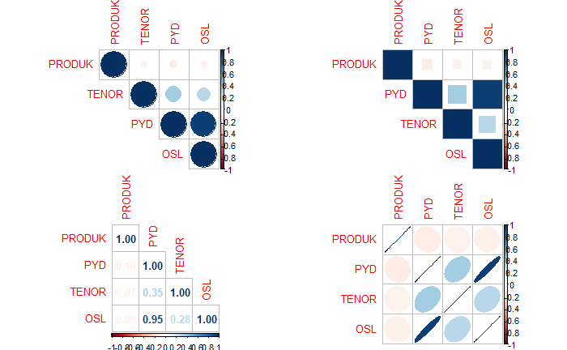

```r
# -- kendall correlation
par(mfrow = c(2,2))
```

```r
corrplot(cor(M, method = "kendall"), type = "upper", order = "hclust")
corrplot(cor(M, method = "kendall"), method = "square", type = "upper")
```

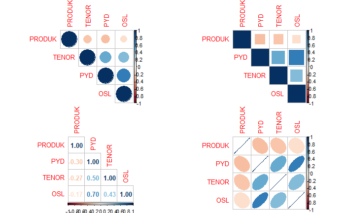

```r
corrplot(cor(M, method = "kendall"), method = "number", type = "lower")
corrplot(cor(M, method = "kendall"), method= "ellipse")
```

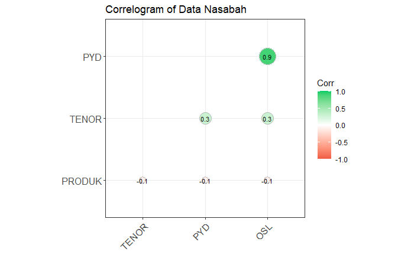

```r
#library ggcorplot
corr = round(cor(M), 1) #Pearson correlation
ggcorrplot(round(cor(M), 1),
          hc.order = TRUE,
          type = "lower",
          lab = TRUE,
          lab_size = 3,
          method = "circle",
          colors = c("tomato2", "white", "springgreen3"),
          title = "Correlogram of Data Nasabah",
          ggtheme = theme_bw)
```

- Pemilihan fitur/independent variabel/input

```r
colnames(data_reduce)
```

```
 [1] "NOMOR_KONTRAK"             "DOMISILI"                  "KARAKTER"                  "PROFESI"
 [5] "KONDISI_USAHA"             "KONDISI_JAMINAN"           "STATUS"                    "PRODUK"
 [9] "PYD"                       "TENOR"                     "OSL"                       "KEWAJIBAN"
[13] "KOLEKTIBILITAS"            "COUNT_SURVEY"              "REKOMENDASI_TINDAK_LANJUT"
```

```r
data_select = data_reduce[,c("KARAKTER", "KONDISI_USAHA", "KONDISI_JAMINAN", "STATUS", "KEWAJIBAN", "OSL", "KOLEKTIBILITAS", "REKOMENDASI_TINDAK_LANJUT")]


data_non_na = na.omit(data_select)
```

2. Pemilihan Variable
- Transformasi Data

```r
data_select_new = data_select
data_select_new$KEWAJIBAN = scale(data_select_new$KEWAJIBAN)[, 1]
data_select_new$OSL = scale(data_select_new$OSL)[, 1]
data_select_new$KEWAJIBAN = cut(data_select_new$KEWAJIBAN, breaks = c(-0.354107, 5, 15, 30))
data_select_new$KEWAJIBAN = as.factor(data_select_new$KEWAJIBAN)
data_select_new$OSL = cut(data_select_new$OSL, breaks = c(-0.60383, 3, 10, 15))
data_select_new$OSL = as.factor(data_select_new$OSL)
data_select_new = na.omit(data_select_new)
```

- Training Data

```r
library(caret)
library(lattice)
index = createDataPartition(data_select_new$REKOMENDASI_TINDAK_LANJUT, p = .95, list = FALSE)
train = data_select_new[index, ]
test = data_select_new[-index, ]
```

- Pemodelan/Modelling

```r
train2 = train
#setting the reference
train2$REKOMENDASI_TINDAK_LANJUT = relevel(train2$REKOMENDASI_TINDAK_LANJUT, ref = "Angsuran Biasa")
#training the model
require(nnet)
#training the multinomial model
multinom_model = multinom(REKOMENDASI_TINDAK_LANJUT ~ ., data = train2)
#checking the model
summary(multinom_model)
```

```
Call:
multinom(formula = REKOMENDASI_TINDAK_LANJUT ~ ., data = train2)

Coefficients:
                 (Intercept) KARAKTERTIDAK KOOPERATIF KONDISI_USAHA KONDISI_JAMINANHilang KONDISI_JAMINANPindah Tangan
Diskon Pelunasan   -3.256901                 1.929303    -0.7692837           -24.1184641                  -26.1239285
Penarikan          -6.870718                 3.733811     0.5581991             0.8100128                    0.5795112
Restrukturisasi    -4.146266                -2.157267     0.9831229             0.5174252                  -13.3583611
                 KONDISI_JAMINANRusak     STATUS KEWAJIBAN(5,15] KEWAJIBAN(15,30]   OSL(3,10] OSL(10,15] KOLEKTIBILITASDIRAGUKAN
Diskon Pelunasan          -23.3011221 0.10415572               0        -3.707248   2.9672598          0               2.8421793
Penarikan                  -0.8728316 0.07594384               0         1.185910 -24.0416739          0               4.4269582
Restrukturisasi             0.6549279 0.32955379               0        26.268573   0.3378521          0              -0.2605969
                 KOLEKTIBILITASKURANG LANCAR KOLEKTIBILITASLANCAR KOLEKTIBILITASMACET
Diskon Pelunasan                   0.2925189            0.1022397           0.5255644
Penarikan                          1.1439265          -28.9283281           1.7387074
Restrukturisasi                   -0.2003699            0.8465481          -3.4263288

Std. Errors:
                 (Intercept) KARAKTERTIDAK KOOPERATIF KONDISI_USAHA KONDISI_JAMINANHilang KONDISI_JAMINANPindah Tangan
Diskon Pelunasan   1.0962741                0.9117268     0.3854299          4.272597e-12                 6.597115e-13
Penarikan          1.1869438                0.6294861     0.3714154          1.139858e+00                 6.615163e-01
Restrukturisasi    0.3541975                0.7824328     0.1036732          1.178700e+00                 1.096285e-06
                 KONDISI_JAMINANRusak     STATUS KEWAJIBAN(5,15] KEWAJIBAN(15,30]    OSL(3,10]   OSL(10,15] KOLEKTIBILITASDIRAGUKAN
Diskon Pelunasan         2.980096e-11 0.14116788             NaN     2.446025e-14 1.050144e+00 1.725746e-15               0.9303683
Penarikan                1.281927e+00 0.10383700    2.468401e-16              NaN 5.930440e-13 3.421049e-17               0.8850904
Restrukturisasi          1.293758e+00 0.03715334    0.000000e+00     1.275736e-12 6.313011e-01 0.000000e+00               0.5984397
                 KOLEKTIBILITASKURANG LANCAR KOLEKTIBILITASLANCAR KOLEKTIBILITASMACET
Diskon Pelunasan                   0.7384310         9.559488e-01           1.2274875
Penarikan                          0.6942279         9.451112e-14           0.7316183
Restrukturisasi                    0.1917471         2.159267e-01           1.1021582

Residual Deviance: 1227.342
AIC: 1305.342
```

```r
#converting the coefficients to odds by taking the exponential of the coefficients.
exp(coef(multinom_model))
```

```
                 (Intercept) KARAKTERTIDAK KOOPERATIF KONDISI_USAHA KONDISI_JAMINANHilang KONDISI_JAMINANPindah Tangan
Diskon Pelunasan 0.038507531                6.8847096     0.4633448          3.353390e-11                 4.513589e-12
Penarikan        0.001037732               41.8382659     1.7475225          2.247937e+00                 1.785166e+00
Restrukturisasi  0.015823395                0.1156408     2.6727900          1.677702e+00                 1.579565e-06
                 KONDISI_JAMINANRusak   STATUS KEWAJIBAN(5,15] KEWAJIBAN(15,30]    OSL(3,10] OSL(10,15] KOLEKTIBILITASDIRAGUKAN
Diskon Pelunasan         7.593662e-11 1.109773               1     2.454497e-02 1.943858e+01          1              17.1531068
Penarikan                4.177669e-01 1.078902               1     3.273665e+00 3.621043e-11          1              83.6764998
Restrukturisasi          1.925004e+00 1.390348               1     2.560331e+11 1.401933e+00          1               0.7705915
                 KOLEKTIBILITASKURANG LANCAR KOLEKTIBILITASLANCAR KOLEKTIBILITASMACET
Diskon Pelunasan                    1.339798         1.107649e+00          1.69141330
Penarikan                           3.139070         2.732667e-13          5.68998352
Restrukturisasi                     0.818428         2.331584e+00          0.03250606
```

```r
head(round(fitted(multinom_model), 2))
```

```
  Angsuran Biasa Diskon Pelunasan Penarikan Restrukturisasi
1           0.81             0.01      0.00            0.18
2           0.49             0.00      0.50            0.01
3           0.28             0.03      0.68            0.00
4           0.97             0.00      0.01            0.03
5           0.44             0.21      0.35            0.00
6           0.68             0.03      0.00            0.29
```

```r
#predicting the values for train dataset
train2$ClassPredicted = predict(multinom_model, newdata = train2, "class")
train_prob = predict(multinom_model, newdata = train2, "probs")
df = train_prob
df$max = apply(df, 1, max)
train2$score = df$max
test_prob = predict(multinom_model, newdata = test, "probs")
df2 = test_prob
df2$max = apply(df2, 1, max)
# Building classification table
tab_train = table(train2$REKOMENDASI_TINDAK_LANJUT, train2$ClassPredicted)
round((sum(diag(tab_train))/sum(tab_train))*100,4)
```

```
[1] 68.3824
```

```r
test$ClassPredicted = predict(multinom_model, newdata = test, "class")
test$score = df2$max
tab_test = table(test$REKOMENDASI_TINDAK_LANJUT, test$ClassPredicted)
round((sum(diag(tab_test))/sum(tab_test))*100,4)
```

```
[1] 70.8333
```